# Progetto di Streaming Data Management and Time Series Analysis

- Studente: Federico Signoretta
- Matricola: 847343
- Anno Accademico 2019/2020
- CdLM Data Science

```python
import numpy as np
np.random.seed(1028)
import time
import pandas as pd
from matplotlib import pyplot as plt
from statsmodels.tsa.stattools import adfuller
from statsmodels.tsa.seasonal import seasonal_decompose
from statsmodels.tsa.arima_model import ARIMA
import statsmodels.api as sm
from pandas.plotting import register_matplotlib_converters
register_matplotlib_converters()
from scipy import stats
import statsmodels.api as sm
import matplotlib.pyplot as plt
from dateutil.relativedelta import relativedelta
from sklearn.metrics import mean_squared_error, mean_absolute_error
from statsmodels.graphics.tsaplots import plot_acf, plot_pacf
import seaborn as sns
from dateutil.parser import parse
import matplotlib as mpl
import matplotlib.pyplot as plt
from statsmodels.tsa.stattools import adfuller
from sklearn.preprocessing import MinMaxScaler,power_transform
from keras.models import Sequential
from keras.layers import Dense, Dropout, TimeDistributed
from keras.layers import LSTM, GRU
plt.style.use('seaborn-pastel')
```

## Import dei dati e prime osservazioni

```python
def test_stationarity(timeseries):
    rolmean = timeseries.rolling(window=30).mean()
    rolstd = timeseries.rolling(window=30).std()

    plt.figure(figsize=(9,4))
    sns.despine(left=True)
    orig = plt.plot(timeseries, color='steelblue',label='Original')
    mean = plt.plot(rolmean, color='lightskyblue', label='Rolling Mean')
    std = plt.plot(rolstd, color='deepskyblue', label = 'Rolling Std')

    plt.legend(loc='best'); plt.title('Rolling Mean & Standard Deviation')
    plt.show()

    print ('<Results of Dickey-Fuller Test>')
    dftest = adfuller(timeseries, autolag='AIC')
    dfoutput = pd.Series(dftest[0:4],
                         index=['Test Statistic','p-value','#Lags Used','Number of Observations Used'])
    for key,value in dftest[4].items():
        dfoutput['Critical Value (%s)'%key] = value
    print(dfoutput)
```

```python
df0 = pd.read_csv('time_series_dataset.csv', sep=';')
df0.head()
```

|  | Data | value |
| --- | --- | --- |
| 0 | 2010-01-01 | 41.651044 |
| 1 | 2010-01-02 | 131.286604 |
| 2 | 2010-01-03 | 117.388117 |
| 3 | 2010-01-04 | 116.461280 |
| 4 | 2010-01-05 | 123.823765 |

Creazione del DataFrame con la colonna 'value' e indice 'Data' con frequenza giornaliera ('D'=daily)

```python
idx = pd.date_range(start=df0['Data'][0], end=df0['Data'][len(df0)-1], freq='D')
df = pd.DataFrame(data=df0.value.values, index=idx, columns=['value'])
df.index.name = 'Data'

df.head()
```

| Data | value |
| --- | --- |
| 2010-01-01 | 41.651044 |
| 2010-01-02 | 131.286604 |
| 2010-01-03 | 117.388117 |
| 2010-01-04 | 116.461280 |
| 2010-01-05 | 123.823765 |

- Visualizzazione dei prezzi serie storica dal 01-01-2010 al 31-12-2018

Dal seguente grafico è possibile notare che tale serie storica potrebbe non soddisfare la condizione di stazionarietà: media e varianza non sembrano essere costanti.

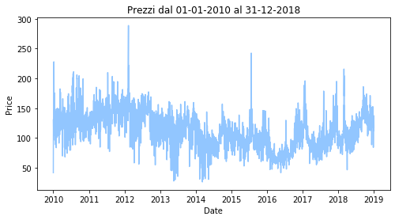

```python
plt.figure(figsize=(8,4))
plt.xlabel('Date')
plt.ylabel('Price')
plt.title('Prezzi dal 01-01-2010 al 31-12-2018')
plt.plot(df)
```

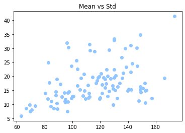

```python
mean = pd.DataFrame(df.groupby(pd.Grouper(level='Data', freq='M')).mean())
std = pd.DataFrame(df.groupby(pd.Grouper(level='Data', freq='M')).std())

plt.figure(figsize=(6,4))
plt.scatter(mean, std)
plt.title('Mean vs Std')
```

Osservando la relazione tra la media mensile e la varianza mensile è possibile osservare che tale relazione si avvicina alla linearità. Pertanto, verrà applicato il logaritmo alla serie.

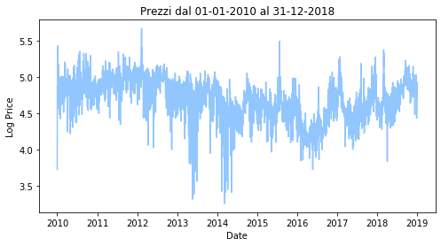

```python
df_log = np.log(df)

plt.figure(figsize=(8,4))
plt.xlabel('Date')
plt.ylabel('Log Price')
plt.title('Prezzi dal 01-01-2010 al 31-12-2018')
plt.plot(df_log)
```

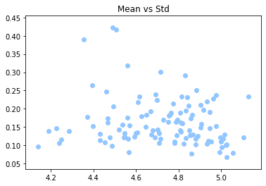

```python
mean = pd.DataFrame(df_log.groupby(pd.Grouper(level='Data', freq='M')).mean())
std = pd.DataFrame(df_log.groupby(pd.Grouper(level='Data', freq='M')).std())

plt.figure(figsize=(6,4))
plt.scatter(mean, std)
plt.title('Mean vs Std')
```

Per verificare la stazionarietà della serie presa in esame è stato eseguito il Dickey-Fuller Test: da tale test è possibile rifiutare l'ipotesi nulla (almeno una radice caratteristica è = 1) ad un livello di significatività del 5%. Ad ogni modo verranno osservati i grafici ACF e PACF per un ulteriore verifica, in quanto ci troviamo difronte ad un caso limite (il $p-value$ è molto vicino alla soglia di accettazione $H_0$. Infatti, all'1% di significatività si può non rifiutare l'ipotesi nulla)

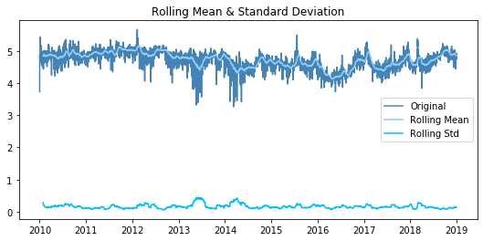

```
<Results of Dickey-Fuller Test>
Test Statistic                   -3.160685
p-value                           0.022376
#Lags Used                       28.000000
Number of Observations Used    3258.000000
Critical Value (1%)              -3.432359
Critical Value (5%)              -2.862428
Critical Value (10%)             -2.567242
dtype: float64
```

```python
 test_stationarity(df_log.value)
```

Dal grafico delle autocorrelazioni è possibile osservare, nella serie differenziata una volta, che il secondo lag ottiene un valore negativo, che ci suggerisce una "over-differenzazione" della serie.

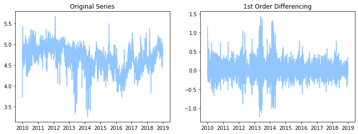

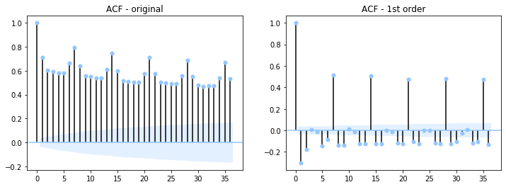

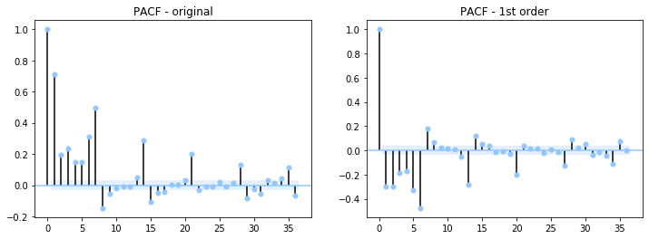

```python
plt.rcParams.update({'figure.figsize':(12,4)})
fig0, axes0 = plt.subplots(1, 2, sharex=True)
# Original Series
axes0[0].plot(df_log.value); axes0[0].set_title('Original Series')
# 1st Differencing
axes0[1].plot(df_log.diff(1).dropna()); axes0[1].set_title('1st Order Differencing')
# 2nd Differencing
plt.show()

# Original Series
fig1, axes1 = plt.subplots(1, 2, sharex=True)
plot_acf(df_log, ax=axes1[0]); axes1[0].set_title('ACF - original')
# 1st Differencing
plot_acf(df_log.diff(1).dropna(), ax=axes1[1]); axes1[1].set_title('ACF - 1st order')
plt.show()

fig2, axes2 = plt.subplots(1, 2, sharex=True)
plot_pacf(df_log, ax=axes2[0]); axes2[0].set_title('PACF - original')
# 1st Differencing
plot_pacf(df_log.diff(1).dropna(), ax=axes2[1]); axes2[1].set_title('PACF - 1st order')
plt.show()
```

```python
from dateutil.relativedelta import relativedelta

relativedelta(df_log.index[-1],df_log.index[0])
```

```
relativedelta(years=+8, months=+11, days=+30)
```

- Divisione della serie storica in TRAINING SET (8 anni) e VALIDATION SET (1 anno)

```python
#split train and test

train = df_log[:'2017-12-31']
relativedelta(train.index[-1],train.index[0])
```

```
relativedelta(years=+7, months=+11, days=+30)
```

```python
val = df_log['2018-01-01':]
relativedelta(val.index[-1],val.index[0])
```

```
relativedelta(months=+11, days=+30)
```

```python
len(train)+len(val) -len(df_log)
```

```
0
```

```python
len(train)
```

```
2922
```

```python
def perc_train_val(df,df_tot):
    return len(df)/len(df_tot)*100
```

Le percentuali relative a TRAINING e VALIDATION sono le seguenti:

```python
print('TRAINING: ', perc_train_val(train,df_log), '%\n',
      'VALIDATION: ', perc_train_val(val,df_log), '%')
```

```
TRAINING:  88.89564952844539 %
 VALIDATION:  11.104350471554609 %
```

## Modello ARIMA

- Creazione e fitting del modello ARIMA (più generalmente definito SARIMAX)

```python
def sarima(data,p,d,q,P=0,D=0,Q=0,s=0,exog=None):

    model = sm.tsa.statespace.SARIMAX(data,
                    order=(p,d,q),
                    seasonal_order=(P, D, Q, s),
                    exog=exog,
                    enforce_stationarity=False,
                    enforce_invertibility=False)

    model_fit = model.fit(disp=0)
    #model_fit.summary()
    return model_fit
```

- Visulazzazione di ACF e PACF dei residui del modello stimato

```python
def acf_pacf_plot(model_fit):
    plt.rcParams.update({'figure.figsize':(12,4)})
    residuals = pd.DataFrame(model_fit.resid)
    fig1, axes1 = plt.subplots(1, 2, sharex=True)
    plot_acf(residuals, lags=400, ax=axes1[0]); axes1[0].set_title('ACF')
    plot_pacf(residuals, lags=400, ax=axes1[1]); axes1[1].set_title('PACF'); axes1[1].set_title('PACF')
    plt.show()
    residuals.describe()
```

- Predizione e valutazione del modello

```python
def pred_eval(model_fit, exog_test=None, exog_train=None):

    pred_val = model_fit.get_prediction(start=val.index[0], end=val.index[-1], exog=exog_test) #model_fit.get_forecast(len(val))
    pred_mean_val = pred_val.predicted_mean

    pred_train = model_fit.get_prediction(start=train.index[0], end=train.index[-1],exog=exog_train)  #model_fit.get_forecast(len(train))
    pred_mean_train = pred_train.predicted_mean

    fig=plt.figure(figsize=(10,5))
    fig.show()
    ax=fig.add_subplot(111)
    plt.title('Prediction vs Actual')
    plt.xlabel('Date')
    plt.ylabel('Log Price')
    plt.xticks(rotation=90)
    ax.plot(train, color='steelblue', label='Training')
    #ax.plot(pred_mean_train[1:], color='red')
    ax.plot(val, color='orange', label='Validation')
    ax.plot(pred_mean_val, color='green', label='Prediction')
    plt.legend()
    plt.show()

    return pred_mean_train, pred_mean_val
```

- Funzione per la valutazione del RMSE su training e validation

```python
def error_eval(pred_mean_train, pred_mean_val):
    rmse_train = mean_squared_error(train[1:], pred_mean_train[1:])**(1/2)
    rmse_val = mean_squared_error(val, pred_mean_val)**(1/2)
    print('RMSE Train: ', rmse_train, '\nRMSE Validation: ', rmse_val)
    return rmse_train, rmse_val
```

Per la parte non stagionale, è possibile rappresentare la serie storica attraverso un modello con parte autoregressiva di ordine 2 e parte di mooving avarage di ordine 1. ARMA(2,1)

```python
model_arima_fit0 = sarima(train,2,0,1)
model_arima_fit0.summary()
```

Statespace Model Results

| Dep. Variable: | value | No. Observations: | 2922 |
| --- | --- | --- | --- |
| Model: | SARIMAX(2, 0, 1) | Log Likelihood | 754.925 |
| Date: | Tue, 25 Feb 2020 | AIC | -1501.850 |
| Time: | 14:11:32 | BIC | -1477.932 |
| Sample: | 01-01-2010 | HQIC | -1493.235 |
|  | - 12-31-2017 |  |  |
| Covariance Type: | opg |  |  |

|  | coef | std err | z | P>\|z\| | [0.025 | 0.975] |
| --- | --- | --- | --- | --- | --- | --- |
| ar.L1 | 1.5849 | 0.016 | 99.628 | 0.000 | 1.554 | 1.616 |
| ar.L2 | -0.5849 | 0.016 | -36.798 | 0.000 | -0.616 | -0.554 |
| ma.L1 | -0.9664 | 0.006 | -164.656 | 0.000 | -0.978 | -0.955 |
| sigma2 | 0.0345 | 0.001 | 61.579 | 0.000 | 0.033 | 0.036 |

| Ljung-Box (Q): | 4259.45 | Jarque-Bera (JB): | 4746.38 |
| --- | --- | --- | --- |
| Prob(Q): | 0.00 | Prob(JB): | 0.00 |
| Heteroskedasticity (H): | 0.79 | Skew: | -0.60 |
| Prob(H) (two-sided): | 0.00 | Kurtosis: | 9.13 |

Warnings:  
[1] Covariance matrix calculated using the outer product of gradients (complex-step).

I coefficienti del modello ARMA(2,1) risultano essere tutti significativi. Passando, invece, all'analisi dei grafici ACF e PACF, è possibile osservare un'integrazione stagionale, in quanto nella ACF le correlazioni tra i residui di ordine multiplo di 7 scendono molto lentamente. Pertanto, verrà inserita una integrazione stagionale di ordine 1 con stagionalità pari a 7. Inoltre, è possibile sosservare una stagionalità annuale.

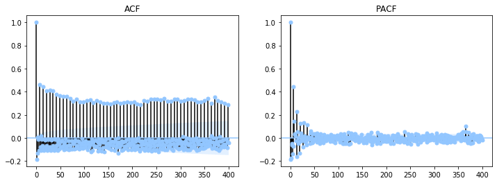

```python
acf_pacf_plot(model_arima_fit0)
```

```python
model_sarima_fit1 = sarima(train,2,0,1,0,1,0,7)
model_sarima_fit1.summary()
```

Statespace Model Results

| Dep. Variable: | value | No. Observations: | 2922 |
| --- | --- | --- | --- |
| Model: | SARIMAX(2, 0, 1)x(0, 1, 0, 7) | Log Likelihood | 1049.214 |
| Date: | Tue, 25 Feb 2020 | AIC | -2090.428 |
| Time: | 14:11:38 | BIC | -2066.520 |
| Sample: | 01-01-2010 | HQIC | -2081.815 |
|  | - 12-31-2017 |  |  |
| Covariance Type: | opg |  |  |

|  | coef | std err | z | P>\|z\| | [0.025 | 0.975] |
| --- | --- | --- | --- | --- | --- | --- |
| ar.L1 | 1.3079 | 0.009 | 139.087 | 0.000 | 1.289 | 1.326 |
| ar.L2 | -0.3264 | 0.007 | -45.285 | 0.000 | -0.341 | -0.312 |
| ma.L1 | -1.0061 | 0.004 | -272.256 | 0.000 | -1.013 | -0.999 |
| sigma2 | 0.0281 | 0.000 | 59.796 | 0.000 | 0.027 | 0.029 |

| Ljung-Box (Q): | 681.29 | Jarque-Bera (JB): | 2508.10 |
| --- | --- | --- | --- |
| Prob(Q): | 0.00 | Prob(JB): | 0.00 |
| Heteroskedasticity (H): | 0.72 | Skew: | 0.08 |
| Prob(H) (two-sided): | 0.00 | Kurtosis: | 7.54 |

Warnings:  
[1] Covariance matrix calculated using the outer product of gradients (complex-step).

I coefficienti risultano essere tutti significativi. Per verificare che la parte stagionale sia stata opportunamente modellata, si osservano nuovamente ACF e PACF dei residui.

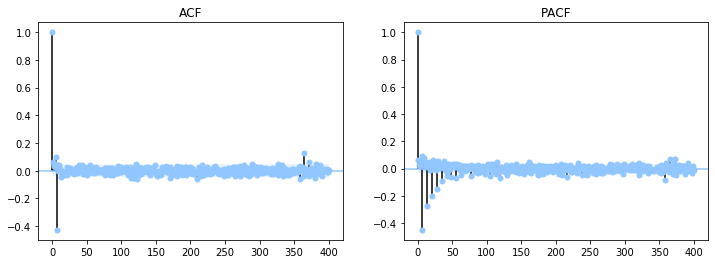

```python
acf_pacf_plot(model_sarima_fit1)
```

Dai grafici ACF e PACF dei residui sembrerebbe esserci ancora una componente Mooving Avarage stagionale, con stagionalità pari a 7. Inoltre, è possible osservare una stagionalità annuale, la quale verrà gestita attraverso opportuni regressori.

```python
# Creazione dei regressori per cogliere la stagionalità annuale
# prepare Fourier terms
exog = pd.DataFrame({'Data': df_log.index})
exog = exog.set_index(pd.PeriodIndex(exog['Data'], freq='D'))
exog['sin365'] = np.sin(2 * np.pi * exog.index.dayofyear / 365.25)
exog['cos365'] = np.cos(2 * np.pi * exog.index.dayofyear / 365.25)
#exog['sin365_2'] = np.sin(4 * np.pi * exog.index.dayofyear / 365.25)
#exog['cos365_2'] = np.cos(4 * np.pi * exog.index.dayofyear / 365.25)
exog = exog.drop(columns=['Data'])
exog_to_train = exog.iloc[:(len(df_log)-365)]
exog_to_test = exog.iloc[(len(df_log)-365):]
```

```python
model_sarima_fit = sarima(train,2,0,1,0,1,1,7, exog=exog_to_train.values)
model_sarima_fit.summary()
```

Statespace Model Results

| Dep. Variable: | value | No. Observations: | 2922 |
| --- | --- | --- | --- |
| Model: | SARIMAX(2, 0, 1)x(0, 1, 1, 7) | Log Likelihood | 1674.075 |
| Date: | Tue, 25 Feb 2020 | AIC | -3334.149 |
| Time: | 14:11:55 | BIC | -3292.328 |
| Sample: | 01-01-2010 | HQIC | -3319.082 |
|  | - 12-31-2017 |  |  |
| Covariance Type: | opg |  |  |

|  | coef | std err | z | P>\|z\| | [0.025 | 0.975] |
| --- | --- | --- | --- | --- | --- | --- |
| x1 | -0.0847 | 0.027 | -3.144 | 0.002 | -0.137 | -0.032 |
| x2 | 0.0640 | 0.025 | 2.571 | 0.010 | 0.015 | 0.113 |
| ar.L1 | 1.1203 | 0.031 | 36.559 | 0.000 | 1.060 | 1.180 |
| ar.L2 | -0.1704 | 0.023 | -7.505 | 0.000 | -0.215 | -0.126 |
| ma.L1 | -1.2817 | 0.046 | -27.906 | 0.000 | -1.372 | -1.192 |
| ma.S.L7 | -0.8381 | 0.007 | -122.695 | 0.000 | -0.851 | -0.825 |
| sigma2 | 0.0112 | 0.001 | 14.011 | 0.000 | 0.010 | 0.013 |

| Ljung-Box (Q): | 71.56 | Jarque-Bera (JB): | 3521.48 |
| --- | --- | --- | --- |
| Prob(Q): | 0.00 | Prob(JB): | 0.00 |
| Heteroskedasticity (H): | 0.72 | Skew: | -0.73 |
| Prob(H) (two-sided): | 0.00 | Kurtosis: | 8.19 |

Warnings:  
[1] Covariance matrix calculated using the outer product of gradients (complex-step).

I coefficienti risultano essere tutti significativi. Per verificare che la parte stagionale di mooving avarage sia stata opportunamente modellata, si osservano nuovamente ACF e PACF dei residui.

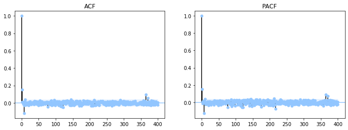

```python
acf_pacf_plot(model_sarima_fit)
```

Osservando i grafici ACF e PACF dei residui di quest'ultimo modello, è possibile affermare che la serie storica è stata opportunamente modellata (anche se i ritardi annuali sono ancora presenti). Di seguito verrà eseguita la valutazione del modello $SARIMAX(2,0,1)(0,1,1)_7$ su training e validation set.

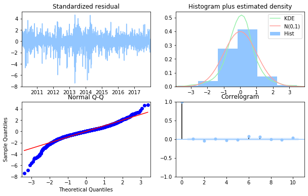

```python
model_sarima_fit.plot_diagnostics(figsize=(10, 6))
plt.show()
```

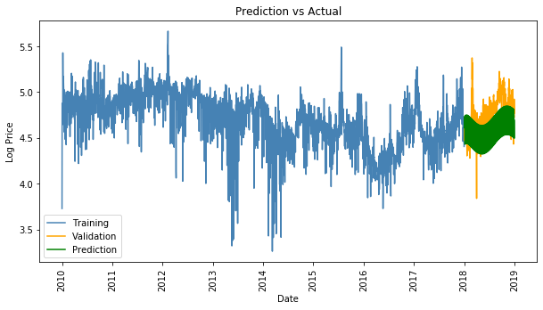

```python
pred_sarima_train, pred_sarima_val  = pred_eval(model_sarima_fit,exog_test=exog_to_test, exog_train=exog_to_train)
```

Dalle predizioni generate dal modello sul training e sul validation, è stato possibile calcolare il RMSE associato ad esse.

```python
mse_sarima_train, mse_sarima_val  = error_eval(pred_sarima_train, pred_sarima_val)
```

```
RMSE Train:  0.16135378808819015
RMSE Validation:  0.22166166168351478
```

- Predictions vs Acutal Values

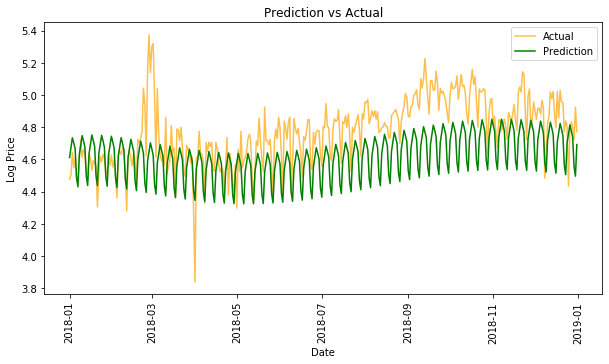

```python
fig=plt.figure(figsize=(10,5))
fig.show()
ax=fig.add_subplot(111)

plt.title('Prediction vs Actual')
plt.xlabel('Date')
plt.ylabel('Log Price')
plt.xticks(rotation=90)

ax.plot(val, color='orange', alpha=.7, label='Actual')
ax.plot(pred_sarima_val, color='green', label='Prediction')
plt.legend()
plt.show()
```

Nota: potrebbero essere inserite maggiori informazioni attraverso i regressori (come festività, etc.)

## Modello UCM

Per il seguente modello UCM sono state utilizzate le seguenti componenti:

- Random Walk con Drift $\mu_t$
- Stagionalità Stocastica di tipo Dummy con $s_1=7$,Stagionalità Trigonometrica con $s_2=365$, $\gamma_t$ con $t=s_1,s_2$
- Ciclo $\psi_t$

Quindi, il modello è dato dalla somma delle componenti: $Y_t = \mu_t + \gamma_t + \psi_t$

```python
model_ucm = sm.tsa.UnobservedComponents(train, 'rwdrift',
                                        cycle = True, seasonal=7,
                                        freq_seasonal=[{'period': 365,"harmonics":20}],
                                        stochastic_seasonal=True)

model_ucm_fit = model_ucm.fit()
model_ucm_fit.summary()
```

Unobserved Components Results

| Dep. Variable: | value | No. Observations: | 2922 |
| --- | --- | --- | --- |
| Model: | random walk with drift | Log Likelihood | 811.009 |
|  | + stochastic seasonal(7) | AIC | -1614.018 |
|  | + stochastic freq_seasonal(365(20)) | BIC | -1590.167 |
|  | + cycle | HQIC | -1605.420 |
| Date: | Tue, 25 Feb 2020 |  |  |
| Time: | 14:15:47 |  |  |
| Sample: | 01-01-2010 |  |  |
|  | - 12-31-2017 |  |  |
| Covariance Type: | opg |  |  |

|  | coef | std err | z | P>\|z\| | [0.025 | 0.975] |
| --- | --- | --- | --- | --- | --- | --- |
| sigma2.level | 0.0210 | 0.000 | 50.227 | 0.000 | 0.020 | 0.022 |
| sigma2.seasonal | 0.0003 | 2.41e-05 | 11.778 | 0.000 | 0.000 | 0.000 |
| sigma2.freq_seasonal_365(20) | 1.54e-11 | 4.42e-07 | 3.49e-05 | 1.000 | -8.66e-07 | 8.66e-07 |
| frequency.cycle | 1.5643 | 0.001 | 1787.831 | 0.000 | 1.563 | 1.566 |

| Ljung-Box (Q): | 408.51 | Jarque-Bera (JB): | 3310.91 |
| --- | --- | --- | --- |
| Prob(Q): | 0.00 | Prob(JB): | 0.00 |
| Heteroskedasticity (H): | 0.50 | Skew: | 0.20 |
| Prob(H) (two-sided): | 0.00 | Kurtosis: | 8.25 |

Warnings:  
[1] Covariance matrix calculated using the outer product of gradients (complex-step).

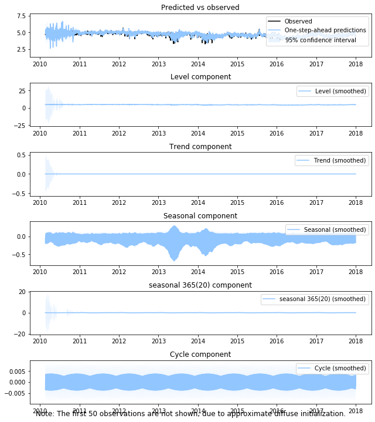

```python
fig = model_ucm_fit.plot_components(figsize=(9, 10))
fig.tight_layout()
```

A questo punto viene fatta una predizione sul training e sul validation set attraverso il modello precdenetemente creato.

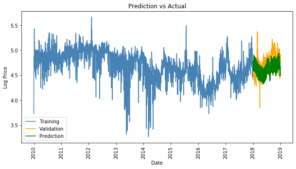

```python
pred_ucm_train, pred_ucm_val  = pred_eval(model_ucm_fit)
```

I valori di RMSE associati al training ed al validation sono i seguenti:

```python
mse_ucm_train, mse_ucm_val  = error_eval(pred_ucm_train, pred_ucm_val) #0.20
```

```
RMSE Train:  0.3197762585194994
RMSE Validation:  0.20966828967529327
```

- Predictions vs Acutal Values

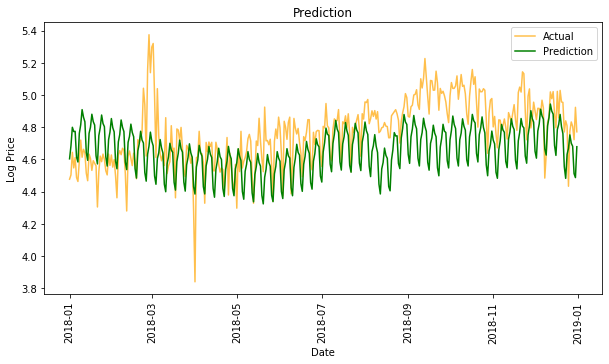

```python
fig=plt.figure(figsize=(10,5))
fig.show()
ax=fig.add_subplot(111)

plt.title('Prediction')
plt.xlabel('Date')
plt.ylabel('Log Price')
plt.xticks(rotation=90)

ax.plot(val, color='orange', alpha=.7, label='Actual')
ax.plot(pred_ucm_val, color='green', label='Prediction')
plt.legend()
plt.show()
```

## Modello ML

#### Recurrent Neural Network: GRU (Gated Recurrent Unit)

- Creazione della variabile target e i suoi $n$ ritardi

```python
def timeseries_sequences(input_data, tw):
    ts = []
    L = len(input_data)
    for i in range(L-tw):
        ts_features = input_data[i:i+tw]
        ts_label = input_data[i+tw:i+tw+1]
        ts.append((ts_features ,ts_label))
    return ts
```

- Costruzione del modello GRU

```python
def RNN_model(n, look_back):
    model = Sequential()
    model.add(GRU(n, input_shape=(1,look_back)))
    #model.add(Dropout(0.5))
    model.add(Dense(1,activation='sigmoid'))
    model.compile(loss='mean_squared_error', optimizer='adam')
    model.summary()
    return model
```

- Fitting del modello

```python
def model_fit(model, ts, n_epochs=10, verbose=1):
    start0 = time.time()
    if verbose == 0:
        for i in range(n_epochs):
            for seq,labels in ts:
                model_fit = model.fit(seq.reshape(1,1,window),labels,epochs=1,shuffle=False,verbose=0)
    else:
        for i in range(n_epochs):
            start = time.time()
            print('Epoch ', i+1, '/', n_epochs, ' -----------------------')
            for seq,labels in ts:
                model_fit = model.fit(seq.reshape(1,1,window),labels,epochs=1,shuffle=False,verbose=0)
            stop = time.time()
            print('-- Execution Time: ',stop-start, 's')


    stop0 = time.time()
    print('\n Global Execution Time: ',stop0-start0, 's')

    return model_fit
```

- Predizione un passo in avanti

```python
def RNN_prediction(model,data, look_back, window_pred ,index,val_data=1):

    if val_data==0:
        prediction = []
        #input_data = data[:look_back].tolist()

        for i in range(window_pred):
            input_data = data[i:look_back+i].tolist()
            seq = np.array(input_data) #[-look_back:])
            pred = model.predict(seq.reshape(1,1,-1))
            prediction.append(pred)
            #input_data.append(pred)

        pred_final = scaler.inverse_transform(np.array(prediction).reshape(-1,1))
        pred_final = pd.DataFrame(pred_final, index=index, columns=['value'])

    else:
        input_data=data[-look_back:].tolist()

        for i in range(window_pred):
            seq = np.array(input_data[-look_back:])
            prediction=model.predict(seq.reshape(1,1,-1))
            input_data.append(prediction)

        pred_final = input_data[-window_pred:]
        pred_final = scaler.inverse_transform(np.array(pred_final).reshape(-1,1))
        pred_final = pd.DataFrame(pred_final, index=index, columns=['value'])

    return pred_final
```

- Visualizzaione delle predizioni

```python
def prediction_plot(pred_train, pred_val, y_train, val):
    plt.style.use('seaborn-pastel')
    fig=plt.figure(figsize=(10,5))
    fig.show()
    ax=fig.add_subplot(111)

    plt.title('Prediction')
    plt.xlabel('Date')
    plt.ylabel('Log Price')
    plt.xticks(rotation=90)
    #ax.plot(y_train, color='steelblue')
    ax.plot(train, color='steelblue', label='Training')
    #ax.plot(pred_train, color='red')
    ax.plot(val, color='orange', label='Validation')
    ax.plot(pred_val, color='green', label='Prediction')
    plt.show()
```

Per prima cosa, vengono normalizzati i dati (tra $0$ e $1$)

```python
scaler = MinMaxScaler()
train_norm = scaler.fit_transform(train.values.reshape(-1,1))
val_norm = scaler.fit_transform(val.values.reshape(-1,1))

series_norm = scaler.fit_transform(df_log.values.reshape(-1,1))
```

Vengono trasformate le serie in target $x$ (un passo in avanti) ed i suoi ritardi $(x-k,\dots,x-1)$, con $k=365$ in questo caso.

```python
window = 365
train_ts = timeseries_sequences(train_norm,window)
series_ts = timeseries_sequences(series_norm,window)
```

Viene creato il modello GRU, composto nel seguente modo:

- input layer con unità pari ai ritardi presi in considerazione
- un hidden layer GRU di 256 unità con funzione di attivazione "tanh" e funzione di attivazione ricorrente "sigmoid" (impostazioni di default).
- un output layer di una unità di tipo Dense con funzione di attivazione "sigmoid" Come funzione di loss è stato utilizzato il "mean_squared_error" e come metodo di ottimizzazione è stato utilizzato "adam".

```python
neurons = 256
model_RNN = RNN_model(n=neurons,look_back=window)
```

```
Model: "sequential_1"
_________________________________________________________________
Layer (type)                 Output Shape              Param #
=================================================================
gru_1 (GRU)                  (None, 256)               477696
_________________________________________________________________
dense_1 (Dense)              (None, 1)                 257
=================================================================
Total params: 477,953
Trainable params: 477,953
Non-trainable params: 0
_________________________________________________________________
```

A questo punto viene fittato il modello sulla serie storica creata precedentemente, impostando il numero di epoche pari a 10.

```python
epochs = 10
model_fit(model_RNN,train_ts, n_epochs=epochs, verbose=1)
```

```
Epoch  1 / 10  -----------------------
-- Execution Time:  31.23722553253174 s
Epoch  2 / 10  -----------------------
-- Execution Time:  28.440176963806152 s
Epoch  3 / 10  -----------------------
-- Execution Time:  28.230713367462158 s
Epoch  4 / 10  -----------------------
-- Execution Time:  27.962451696395874 s
Epoch  5 / 10  -----------------------
-- Execution Time:  28.10883092880249 s
Epoch  6 / 10  -----------------------
-- Execution Time:  28.315279245376587 s
Epoch  7 / 10  -----------------------
-- Execution Time:  28.269402503967285 s
Epoch  8 / 10  -----------------------
-- Execution Time:  28.250452280044556 s
Epoch  9 / 10  -----------------------
-- Execution Time:  28.14300227165222 s
Epoch  10 / 10  -----------------------
-- Execution Time:  28.160693407058716 s

 Global Execution Time:  285.13490867614746 s
```

```
<keras.callbacks.callbacks.History at 0x22d2f630b08>
```

Di seguito vengono riportate le predizioni sul validation set e relativi RMSE associati a training set e validation set

```python
pred_val = RNN_prediction(model_RNN,train_norm, look_back=window, window_pred=365, index=val.index)
```

```python
pred_train = RNN_prediction(model_RNN,train_norm, look_back=window, window_pred=len(train)-window,
                            index=train[window:].index, val_data=0)
```

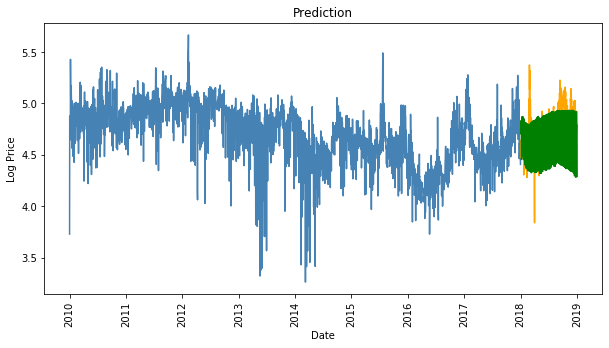

```python
prediction_plot(pred_train, pred_val, train[window:], val)
```

```python
mse_gru_train = mean_squared_error(train[window:], pred_train)**(1/2)
print('RMSE Training: ', mse_gru_train)

mse_gru_val = mean_squared_error(val.value, pred_val.value)**(1/2)
print('RMSE Validation: ', mse_gru_val)
```

```
RMSE Training:  0.31087865833377926
RMSE Validation:  0.2114154290836964
```

- Predictions vs Acutal Values

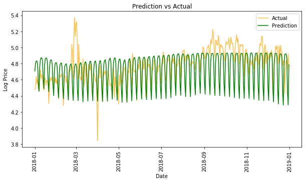

```python
fig=plt.figure(figsize=(10,5))
fig.show()
ax=fig.add_subplot(111)

plt.title('Prediction vs Actual')
plt.xlabel('Date')
plt.ylabel('Log Price')
plt.xticks(rotation=90)

ax.plot(val, color='orange', alpha=.7, label='Actual')
ax.plot(pred_val, color='green', label='Prediction')
plt.legend()
plt.show()
```

# Confronto tra i modelli

In conclusione, vengono presentati i valori di RMSE per ogni modello sia sul training set che sul validation set.

```python
rmse_val = [mse_sarima_val]
rmse_val.append(mse_ucm_val)
rmse_val.append(mse_gru_val)

rmse_train = [mse_sarima_train]
rmse_train.append(mse_ucm_train)
rmse_train.append(mse_gru_train)

rmse_val = pd.DataFrame(data=rmse_val, index=['SARIMA', 'UCM', 'GRU'], columns=['RMSE Validation'])
rmse_train = pd.DataFrame(data=rmse_train, index=['SARIMA', 'UCM', 'GRU'], columns=['RMSE Training'])

pd.concat([rmse_val, rmse_train], axis=1)
```

|  | RMSE Validation | RMSE Training |
| --- | --- | --- |
| SARIMA | 0.221662 | 0.161354 |
| UCM | 0.209668 | 0.319776 |
| GRU | 0.211415 | 0.310879 |

Dunque, è possibile osservare che le performance sui modelli sono simili tra loro.

# Forecast dal 01-01-2019 al 30-11-2019

- SARIMA
- UCM
- RNN: GRU

```python
test_datetime = pd.date_range(start='01-01-2019', end='30-11-2019')
date_fourier = pd.date_range(start='01-01-2010', end='30-11-2019')
```

```python
df_fourier = pd.DataFrame(index=date_fourier)
```

### Forecast col modello SARIMA

```python
# prepare Fourier terms
exog = pd.DataFrame({'Data': df_fourier.index})
exog = exog.set_index(pd.PeriodIndex(exog['Data'], freq='D'))
exog['sin365'] = np.sin(2 * np.pi * exog.index.dayofyear / 365.25)
exog['cos365'] = np.cos(2 * np.pi * exog.index.dayofyear / 365.25)
#exog['sin365_2'] = np.sin(4 * np.pi * exog.index.dayofyear / 365.25)
#exog['cos365_2'] = np.cos(4 * np.pi * exog.index.dayofyear / 365.25)
exog = exog.drop(columns=['Data'])

exog_to_train = exog[:'31-12-2018']
exog_to_test = exog['01-01-2019':]
```

```python
model_sarima_fit_2019 = sarima(df_log,2,0,1,0,1,1,7, exog=exog_to_train.values)
```

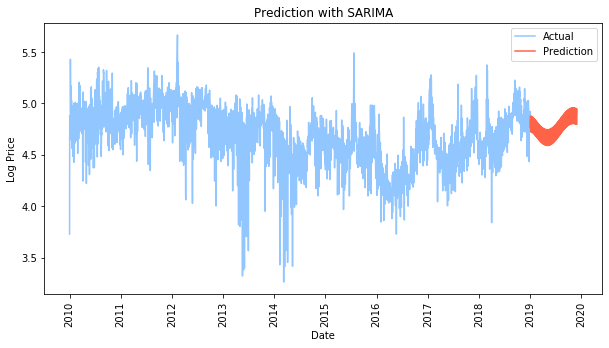

```python
pred_test_2019_sarima = model_sarima_fit_2019.get_prediction(start=test_datetime[0], end=test_datetime[-1],
                                                               exog = exog_to_test )
pred_mean_test_2019_sarima = pred_test_2019_sarima.predicted_mean


fig=plt.figure(figsize=(10,5))
fig.show()
ax=fig.add_subplot(111)


plt.title('Prediction with SARIMA')
plt.xlabel('Date')
plt.ylabel('Log Price')
plt.xticks(rotation=90)
ax.plot(df_log, label='Actual')
ax.plot(pred_mean_test_2019_sarima,color='tomato', label='Prediction')
plt.legend()
plt.show()
```

### Forecast col modello UCM

```python
model_ucm_2019 = sm.tsa.UnobservedComponents(df_log, 'rwdrift',
                                             cycle = True, seasonal = 7,
                                             freq_seasonal=[{'period': 365,"harmonics":20}],
                                             stochastic_seasonal = True)

model_ucm_fit_2019 = model_ucm_2019.fit()
```

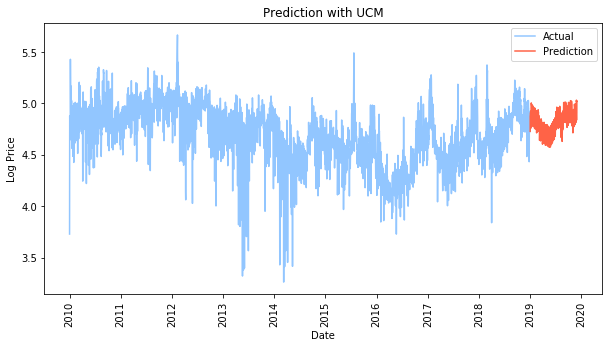

```python
pred_test_2019_ucm = model_ucm_fit_2019.get_prediction(start=test_datetime[0], end=test_datetime[-1])
pred_mean_test_2019_ucm = pred_test_2019_ucm.predicted_mean


fig=plt.figure(figsize=(10,5))
fig.show()
ax=fig.add_subplot(111)


plt.title('Prediction with UCM')
plt.xlabel('Date')
plt.ylabel('Log Price')
plt.xticks(rotation=90)
ax.plot(df_log, label='Actual')
ax.plot(pred_mean_test_2019_ucm, color='tomato', label='Prediction')
plt.legend()
plt.show()
```

### Forecast col modello GRU

```python
model_GRU_final = RNN_model(n=neurons,look_back=window)

model_fit(model_GRU_final,series_ts, n_epochs=epochs, verbose=0)

pred_test_2019_gru = RNN_prediction(model_GRU_final,series_norm, look_back=window,
                                    window_pred=len(test_datetime), index=test_datetime)

#Nota: forse sarebbe meglio salavare i pesi della rete trainata precedentemente
```

```
Model: "sequential_2"
_________________________________________________________________
Layer (type)                 Output Shape              Param #
=================================================================
gru_2 (GRU)                  (None, 256)               477696
_________________________________________________________________
dense_2 (Dense)              (None, 1)                 257
=================================================================
Total params: 477,953
Trainable params: 477,953
Non-trainable params: 0
_________________________________________________________________

 Global Execution Time:  371.277791261673 s
```

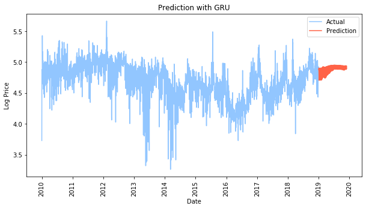

```python
#prediction vs actual

fig=plt.figure(figsize=(10,5))
fig.show()
ax=fig.add_subplot(111)

plt.title('Prediction with GRU')
plt.xlabel('Date')
plt.ylabel('Log Price')
plt.xticks(rotation=90)

ax.plot(df_log, label='Actual')
ax.plot(pred_test_2019_gru, color='tomato', label='Prediction')
plt.legend()
plt.show()
```

#### Creazione della tabella coi valori delle previsioni ottenuti dai 3 modelli

```python
test_data = pd.DataFrame(test_datetime, index=test_datetime)

prediction_all_models = pd.concat([test_data, np.exp(pred_mean_test_2019_sarima +1/2*pred_mean_test_2019_sarima.var()),
                                   np.exp(pred_mean_test_2019_ucm+1/2*pred_mean_test_2019_ucm.var()),
                                   np.exp(pred_test_2019_gru + 1/2*pred_test_2019_gru.var())],axis=1)

prediction_all_models.columns = ['Data','ARIMA', 'UCM', 'ML']
prediction_all_models = prediction_all_models.reset_index().drop('index', axis=1)
```

```python
prediction_all_models
```

|  | Data | ARIMA | UCM | ML |
| --- | --- | --- | --- | --- |
| 0 | 2019-01-01 | 118.498553 | 113.823560 | 131.458374 |
| 1 | 2019-01-02 | 128.035501 | 132.298095 | 132.156448 |
| 2 | 2019-01-03 | 130.188704 | 132.627264 | 134.845612 |
| 3 | 2019-01-04 | 131.950764 | 136.908689 | 133.567200 |
| 4 | 2019-01-05 | 113.868317 | 117.277908 | 118.452133 |
| ... | ... | ... | ... | ... |
| 329 | 2019-11-26 | 128.865629 | 135.759566 | 138.886917 |
| 330 | 2019-11-27 | 137.828938 | 154.162189 | 139.278259 |
| 331 | 2019-11-28 | 139.781760 | 151.675670 | 139.941040 |
| 332 | 2019-11-29 | 141.508746 | 153.163133 | 139.017502 |
| 333 | 2019-11-30 | 122.015347 | 127.714521 | 133.635300 |

334 rows × 4 columns

```python
prediction_all_models.describe()
```

|  | ARIMA | UCM | ML |
| --- | --- | --- | --- |
| count | 334.000000 | 334.000000 | 334.000000 |
| mean | 119.486645 | 126.690293 | 135.164062 |
| std | 11.368469 | 13.754200 | 6.771827 |
| min | 98.961704 | 97.462574 | 110.661209 |
| 25% | 111.731744 | 117.941652 | 132.587688 |
| 50% | 118.529386 | 125.083436 | 137.322266 |
| 75% | 127.708020 | 137.638002 | 140.039257 |
| max | 142.994147 | 154.162189 | 141.829697 |

```python
prediction_all_models.to_csv('SDMTSA_847343_0.csv')
```